# Análise de Componentes Principais

## Introdução

Análise de Componentes Principais é uma técnica estatística que transforma linearmente um conjunto de $p$ variáveis em um conjunto com um número menor ($k$) de variáveis não-correlacionadas, que explica uma parcela substancial das informações do conjunto original. As $p$ variáveis originais $(X_{1},\ldots,X_{p})$ são tranformadas em $k$ variáveis $(Y_{1},\ldots,Y_{k})$, denominadas componentes principais, de modo que $Y_{1}$ é aquela que explica a maior parcela de variabilidade total dos dados, $Y_{2}$ explica a segunda maior parcela e assim por diante.

Os principais objetivos da análise de componentes principais são:

- redução da dimensionalidade dos dados;
- obtenção de combinações interpretáveis das variáveis;
- descrição e entendimento da estrutura de correlação das variáveis;

A análise é realizada com o intuito de resumir o padrão de correlação entre as variáveis e muitas vezes é possível chegar a conjuntos de variáveis que sejam não correlacionados uns com os outros, levando assim a um agrupamento delas.

Algebricamente, as componentes principais são combinações lineares das variáveis originais. Essa análise depende somente da matriz de covariância ($\Sigma$) ou da matriz de correlação ($\rho$) de $X_{1},\ldots,X_{p}$. Não requer qualquer suposição sobre a forma da distribuição multivariada dessas variáveis. Segundo Tabachnick e Fidell (2001), se a normalidade existe, a análise é engrandecida, senão ela ainda vale a pena.

## Aplicação Prática

### Pacotes Utilizados

Para a demonstração de um exemplo prático da técnica de análise de componentes principais, serão utilizados os pacotes `factoextra` e `FactoMineR`. Além das funções a serem utilizadas, a base de dados exemplo está presente no pacote `factoextra`. Ao carregar os pacotes, outros pacotes como `ggplot2` e `psych` são carregados automaticamente. Eles serão importantes para os cálculos e construções de gráficos.

```r
library(factoextra)
library(FactoMineR)
library(tidyverse)
```

### Importação da Base de Dados

```r
data("decathlon2", package = "factoextra")
```

A base de dados contém informações das perfomances dos atletas durante dois eventos esportivos. Nós iremos utilizar apenas as performances dos atletas provenientes dos eventos das Olimpíadas.

```r
dados_olimpiadas <- decathlon2 %>% filter(Competition == "OlympicG") %>% .[,1:10]
head(dados_olimpiadas)
```

```
##           X100m Long.jump Shot.put High.jump X400m X110m.hurdle Discus
## Sebrle    10.85      7.84    16.36      2.12 48.36        14.05  48.72
## Clay      10.44      7.96    15.23      2.06 49.19        14.13  50.11
## Karpov    10.50      7.81    15.93      2.09 46.81        13.97  51.65
## Macey     10.89      7.47    15.73      2.15 48.97        14.56  48.34
## Warners   10.62      7.74    14.48      1.97 47.97        14.01  43.73
## Zsivoczky 10.91      7.14    15.31      2.12 49.40        14.95  45.62
##           Pole.vault Javeline X1500m
## Sebrle           5.0    70.52 280.01
## Clay             4.9    69.71 282.00
## Karpov           4.6    55.54 278.11
## Macey            4.4    58.46 265.42
## Warners          4.9    55.39 278.05
## Zsivoczky        4.7    63.45 269.54
```

Nota-se que as variáveis possuem escalas diferentes. Isso é um fator importante para a aplicação da ánalise de componentes principais. Padronizar implica atribuir igual importância a todas as variáveis. Para contornar essa característica, é realizada a padronização dos dados. Essa discussão será apresentada ao longo do material.

## PCA - Sem Padronização

### Criação dos Componentes

Para a realização da análise de componentes principais, serão utilizadas apenas as variáveis numéricas referentes Às performances dos atletas presentes na base de dados. Utiliza-se a função PCA, cujos principais argumentos de entrada são:

- **X**: um dataframe com n linhas e p colunas contendo as variáveis numéricas com as quais serão aplicados o PCA.
- **scale.unit**: um argumento booleano que indica a realização do processo de padronização das variáveis.
- **ncp**: número de componentes principais máximos a serem calculados.
- **graph**: um argumento que indica a construção de gráficos dos componentes.

Para saber mais sobre a função e o pacote acesse a [documentação do pacote.](https://cran.r-project.org/web/packages/FactoMineR/FactoMineR.pdf)

Nesse primeiro instante, não iremos aplicar a padronização das variáveis. Isso será discutido no próximo tópico.

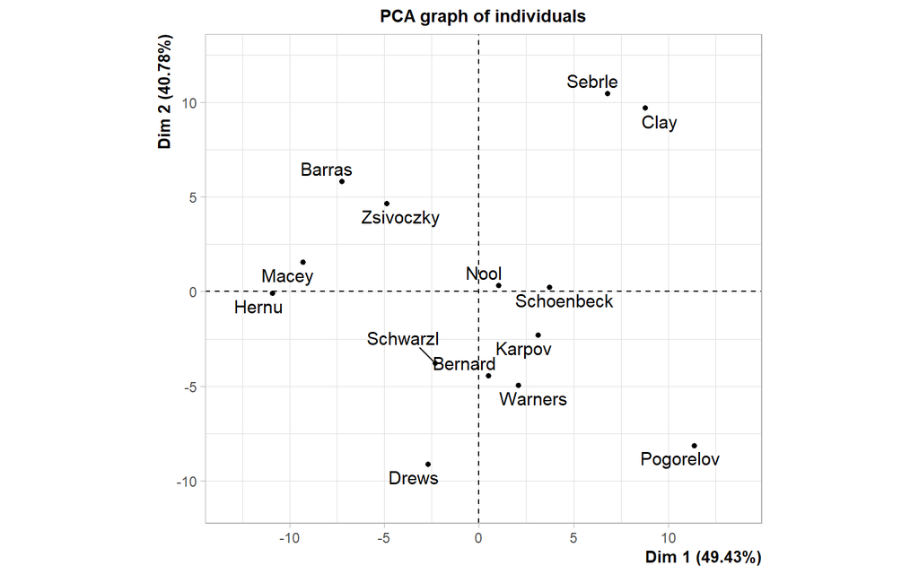

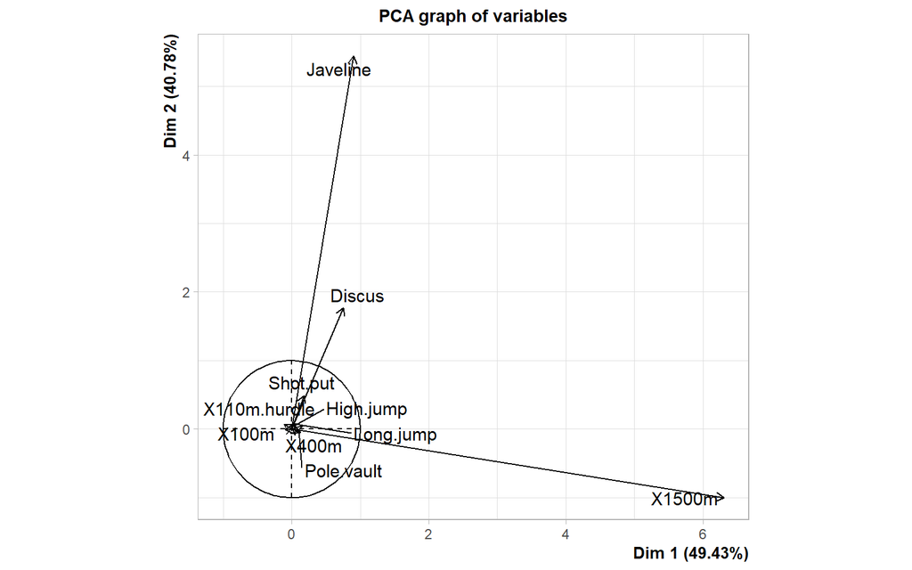

```r
pca=PCA(dados_olimpiadas, scale.unit = FALSE, graph = TRUE)
```

O gráfico 1 apresenta os resultados das 2 componentes principais referentes a cada indivíduo. Esses resultados estão apresentados em forma de coordenadas. Mais a frente serão apresentados os resultados referentes a todos as componentes calculadas.

O gráfico 2 apresenta os resultados das influências das variáveis da base de dados nas componentes principais criadas. Podemos observar que as cargas são muito discrepantes, principalmente em relação às variáveis x1500 e Javeline. Isso se dá em razão da não padronização dos dados.

O objeto `pca` é uma lista de informações sobre a análise de componentes principais realizada. Para saber mais sobre essas informações, acesse o objeto criado.

```r
pca
```

```
## **Results for the Principal Component Analysis (PCA)**
## The analysis was performed on 14 individuals, described by 10 variables
## *The results are available in the following objects:
##
##    name               description
## 1  "$eig"             "eigenvalues"
## 2  "$var"             "results for the variables"
## 3  "$var$coord"       "coord. for the variables"
## 4  "$var$cor"         "correlations variables - dimensions"
## 5  "$var$cos2"        "cos2 for the variables"
## 6  "$var$contrib"     "contributions of the variables"
## 7  "$ind"             "results for the individuals"
## 8  "$ind$coord"       "coord. for the individuals"
## 9  "$ind$cos2"        "cos2 for the individuals"
## 10 "$ind$contrib"     "contributions of the individuals"
## 11 "$call"            "summary statistics"
## 12 "$call$centre"     "mean of the variables"
## 13 "$call$ecart.type" "standard error of the variables"
## 14 "$call$row.w"      "weights for the individuals"
## 15 "$call$col.w"      "weights for the variables"
```

A variância retida em cada um dos componentes é medida pelos “autovalores” (eigenvalues), que podem ser extraídos utilizando a função `get_eigenvalue()`:

```r
(autovalores = get_eigenvalue(pca))
```

```
##          eigenvalue variance.percent cumulative.variance.percent
## Dim.1  41.220440299     49.429679325                    49.42968
## Dim.2  34.010653559     40.784030614                    90.21371
## Dim.3   7.232499274      8.672884550                    98.88659
## Dim.4   0.709285877      0.850543400                    99.73714
## Dim.5   0.124644020      0.149467446                    99.88661
## Dim.6   0.047837646      0.057364732                    99.94397
## Dim.7   0.024980958      0.029956030                    99.97393
## Dim.8   0.018344697      0.021998127                    99.99592
## Dim.9   0.001763853      0.002115132                    99.99804
## Dim.10  0.001635022      0.001960644                   100.00000
```

A escolha de quantos componentes principais deve ser realizada através:

- Do percentual de variância explicada;
- Do número de autovalores maiores do que 1 (critério Kaiser);
- Do gráfico screeplot;
- Da experiência do pesquisador.

Autovaloes superiores a 1 indicam que a variância do componente é superior ao que representaria a variância dos dados originais, sendo possível utilizar inclusive como ponto de corte para decidir quantos componentes utilizar. Observa-se que no exemplo acima, foram criados 10 componentes principais, dos quais os três primeiros explicam 98,88% da variação.

Para visualizar melhor a variância explicada, podemos plotar o seguinte gráfico:

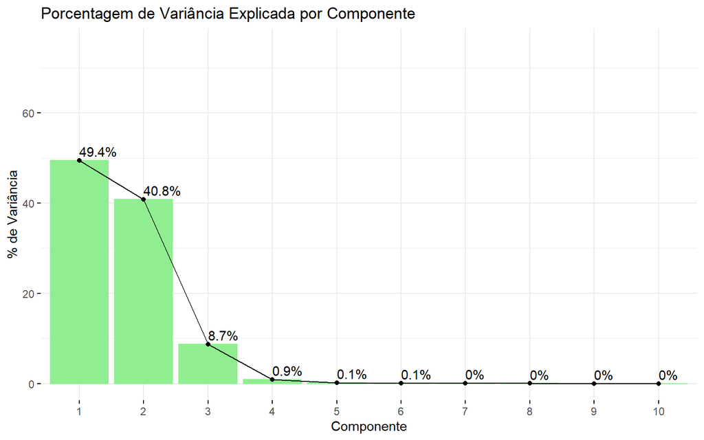

```r
fviz_eig(pca, barfill = "lightgreen",barcolor = "lightgreen", addlabels = T,ylim=c(0,75)) + ggtitle("Porcentagem de Variância Explicada por Componente") + ylab("% de Variância") + xlab("Componente")
```

Nota-se através do gráfico que o 1ª componente explica 49,4% da variância total dos dados. Ou seja, quase metade das informações contidas nas 10 variáveis do banco podem ser encapsulada apenas nessa componente. O 2ª componente explica 40,8% da variância total e o 3ª componente explica 8,7%. Com apenas 3 componentes temos que 98,88% da variância dos dados é explicada.

Outra possibilidade é escolher o número de componentes através do screeplot:

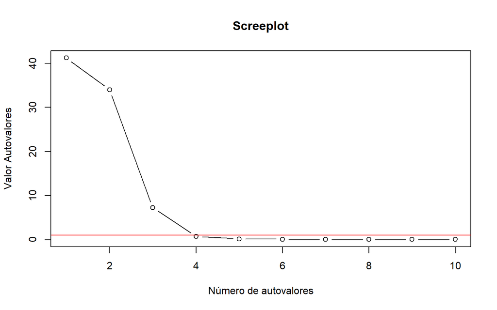

```r
plot(pca$eig[,1], main = "Screeplot", type = "b", ylab = "Valor Autovalores", xlab = "Número de autovalores", axes = T)
abline(h=1, col="red")
```

Através do screeplot, temos a escolha de 3 componentes.

Assim, através dos diversos critérios, foi decidido a utilização de apenas 3 componentes. Para ter acesso às cargas fatoriais de cada variável, utiliza-se a função `get_pca_var()`:

```r
variaveis=get_pca_var(pca)
variaveis$coord[,1:3]
```

```
##                     Dim.1       Dim.2       Dim.3
## X100m        -0.093584547 -0.00970881 -0.08957883
## Long.jump     0.160161098  0.05131001  0.09817583
## Shot.put      0.179333199  0.49198234  0.49270198
## High.jump     0.003483113  0.03007968  0.06438105
## X400m         0.125559285 -0.04602256 -0.48876892
## X110m.hurdle -0.110300599  0.07479956 -0.08765203
## Discus        0.750717894  1.76846814  2.42965579
## Pole.vault    0.107874707 -0.02178301 -0.17542501
## Javeline      0.903210274  5.44266760 -0.87064358
## X1500m        6.303564362 -1.00333316 -0.17128019
```

Logo,

> - Equação `Dim1`:

$Y_{Dim1} = X_{x100m} \times$ `-0.0936` + $X_{Long.jump} \times$ `0.1602` + $X_{Shot.put} \times$ `0.1793` + $X_{High.jump} \times$ `0.0035` + $X_{X400m} \times$ `0.1256` + $X_{X110m.hurdle} \times$ `-0.1103` + $X_{Discus} \times$ `0.7507` + $X_{Pole.vault} \times$ `0.1079` + $X_{Javeline} \times$ `0.9032` + $X_{X1500m} \times$ `6.3036`

> - Equação `Dim2`:

$Y_{Dim2} = X_{x100m} \times$ `-0.0097` + $X_{Long.jump} \times$ `0.0513` + $X_{Shot.put} \times$ `0.492` + $X_{High.jump} \times$ `0.0301` + $X_{X400m} \times$ `-0.046` + $X_{X110m.hurdle} \times$ `0.0748` + $X_{Discus} \times$ `1.7685` + $X_{Pole.vault} \times$ `-0.0218` + $X_{Javeline} \times$ `5.4427` + $X_{X1500m} \times$ `-1.0033`

> - Equação `Dim3`:

$Y_{Dim3} = X_{x100m} \times$ `-0.0896` + $X_{Long.jump} \times$ `0.0982` + $X_{Shot.put} \times$ `0.4927` + $X_{High.jump} \times$ `0.0644` + $X_{X400m} \times$ `-0.4888` + $X_{X110m.hurdle} \times$ `-0.0877` + $X_{Discus} \times$ `2.4297` + $X_{Pole.vault} \times$ `-0.1754` + $X_{Javeline} \times$ `-0.8706` + $X_{X1500m} \times$ `-0.1713`

### Cálculo dos Componentes

Para acessar os valores das componentes para cada atleta, utiliza-se a função `get_pca_ind()`:

```r
# Extract the results for individuals
ind <- get_pca_ind(pca)
ind$coord[,1:3]
```

```
##                  Dim.1       Dim.2      Dim.3
## Sebrle       6.7850405 10.48706102 -0.4860443
## Clay         8.7779844  9.71120866  0.5678759
## Karpov       3.1114714 -2.30125683  7.3731429
## Macey       -9.3149894  1.57443514  3.7862809
## Warners      2.0883636 -4.96612247 -0.2365096
## Zsivoczky   -4.8994834  4.65974834 -0.7497504
## Hernu      -10.9183190 -0.09040184  0.6245921
## Bernard      0.4954392 -4.44932102  0.7016404
## Schwarzl    -2.3315475 -3.77432603 -1.8802325
## Pogorelov   11.3781879 -8.13263462  0.1308965
## Schoenbeck   3.7321847  0.24569358 -1.8669335
## Barras      -7.2524420  5.82476294 -1.7306657
## Nool         1.0360407  0.34439577 -3.8349128
## Drews       -2.6879312 -9.13324265 -2.3993799
```

## PCA - Com Padronização

### Padronização das Variáveis

Dessa vez utilizaremos a função aplicando a padronização. Para isso, atribui-se **TRUE** ao argumento de entrada `scale.unit`. Nesse caso iremos também construir os gráficos de forma manual, apresentando novas ferramentas presentes no pacote. Para não construção automática dos gráficos, atribui-se **FALSE** ao argumento de entrada `graph`.

```r
pca=PCA(dados_olimpiadas, graph=FALSE, scale.unit = T)
```

Para a construção do gráfico referente às influências das variáveis nos componentes constrúidos, utilza-se a função `fviz_pca_var()` da seguinte forma:

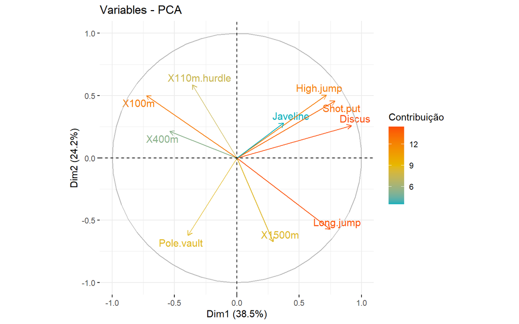

```r
fviz_pca_var(pca,
             col.var = "contrib", # Cor por contribuições para o PC
             gradient.cols = c("#00AFBB", "#E7B800", "#FC4E07"),
             repel = TRUE,
             legend.title = "Contribuição"
)
```

O gráfico, agora que os dados estão padronizados, apresenta uma contribuição das variáveis mais homogênea. Nota-se que há variáveis que contribuem mais nos cálculos de certos componentes, enquanto que outras, contribuem de maneira similar. Isso é notado através das direções dos vetores.

Ao acessar os autovalores, temos:

```r
(autovalores = get_eigenvalue(pca))
```

```
##        eigenvalue variance.percent cumulative.variance.percent
## Dim.1  3.85464972       38.5464972                    38.54650
## Dim.2  2.41792403       24.1792403                    62.72574
## Dim.3  1.51048197       15.1048197                    77.83056
## Dim.4  0.94509143        9.4509143                    87.28147
## Dim.5  0.55197568        5.5197568                    92.80123
## Dim.6  0.31867424        3.1867424                    95.98797
## Dim.7  0.21053123        2.1053123                    98.09328
## Dim.8  0.11426352        1.1426352                    99.23592
## Dim.9  0.05979070        0.5979070                    99.83383
## Dim.10 0.01661748        0.1661748                   100.00000
```

Autovalores superiores a 1 indicam que a variância do componente é superior ao que representaria a variância dos dados originais, sendo possível utilizar inclusive como ponto de corte para decidir quantos componentes utilizar. Observa-se que no exemplo acima, foram criados 10 componentes principais, dos quais os quatro primeiros explicam 87,28% da variação.

Para visualizar melhor a variância explicada, podemos plotar o seguinte gráfico:

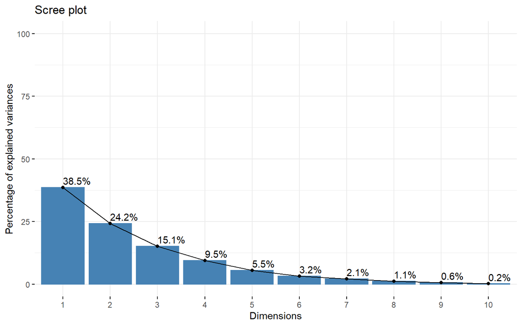

```r
fviz_eig(pca, addlabels=TRUE, ylim = c(0,100))
```

Nota-se através do gráfico que, a 1ª componente explica 38,5% da variância total dos dados. Ou seja, aproximadamente 2/5 das informações contidas nas 10 variáveis do banco podem ser encapsulada apenas nessa componente. A 2ª componente explica 24,2% da variância total, a 3ª componente explica 15,1% e a 4ª componente explica apenas 9,5%. Assim, com apenas 4 componentes, temos que 87,28% da variância dos dados é explicada.

Outra possibilidade é escolher o número de componentes através do screeplot:

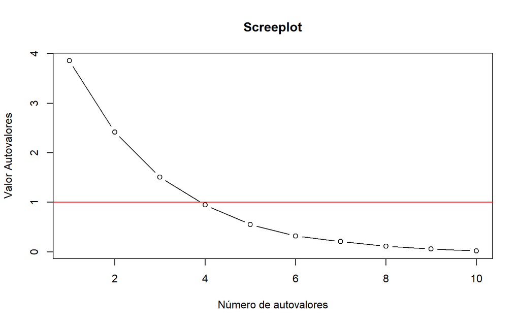

```r
plot(pca$eig[,1], main = "Screeplot", type = "b", ylab = "Valor Autovalores", xlab = "Número de autovalores", axes = T)
abline(h=1, col="red")
```

```r
variaveis=get_pca_var(pca)
variaveis$coord[,1:4]
```

```
##                   Dim.1      Dim.2       Dim.3       Dim.4
## X100m        -0.7265091  0.5005299  0.10527705  0.11085540
## Long.jump     0.7477982 -0.5727170  0.09859835 -0.14885923
## Shot.put      0.7846265  0.4568396  0.27289406  0.10400947
## High.jump     0.7171136  0.5064065 -0.07950231  0.28173580
## X400m        -0.5375910  0.2121152  0.52672688  0.55777995
## X110m.hurdle -0.3564187  0.5866040  0.36988423 -0.29503533
## Discus        0.9176101  0.2599701  0.09872770  0.01410823
## Pole.vault   -0.3929727 -0.6225983  0.55478859 -0.23372429
## Javeline      0.3754295  0.2804259  0.70340042 -0.37399916
## X1500m        0.2903786 -0.6717813  0.42698954  0.47705831
```

Logo,

> - Equação `Dim1`:

$Y_{Dim1} = Z_{x100m} \times$ `-0.7265` + $Z_{Long.jump} \times$ `0.7478` + $Z_{Shot.put} \times$ `0.7846` + $Z_{High.jump} \times$ `0.7171` + $Z_{X400m} \times$ `-0.5376` + $Z_{X110m.hurdle} \times$ `-0.3564` + $Z_{Discus} \times$ `0.9176` + $Z_{Pole.vault} \times$ `-0.393` + $Z_{Javeline} \times$ `0.3754` + $Z_{X1500m} \times$ `0.2904`

> - Equação `Dim2`:

$Y_{Dim2} = Z_{x100m} \times$ `0.5005` + $Z_{Long.jump} \times$ `-0.5727` + $Z_{Shot.put} \times$ `0.4568` + $Z_{High.jump} \times$ `0.5064` + $Z_{X400m} \times$ `0.2121` + $Z_{X110m.hurdle} \times$ `0.5866` + $Z_{Discus} \times$ `0.26` + $Z_{Pole.vault} \times$ `-0.6226` + $Z_{Javeline} \times$ `0.2804` + $Z_{X1500m} \times$ `-0.6718`

> - Equação `Dim3`:

$Y_{Dim3} = Z_{x100m} \times$ `0.1053` + $Z_{Long.jump} \times$ `0.0986` + $Z_{Shot.put} \times$ `0.2729` + $Z_{High.jump} \times$ `-0.0795` + $Z_{X400m} \times$ `0.5267` + $Z_{X110m.hurdle} \times$ `0.3699` + $Z_{Discus} \times$ `0.0987` + $Z_{Pole.vault} \times$ `0.5548` + $Z_{Javeline} \times$ `0.7034` + $Z_{X1500m} \times$ `0.427`

> - Equação `Dim4`:

$Y_{Dim4} = Z_{x100m} \times$ `0.1109` + $Z_{Long.jump} \times$ `-0.1489` + $Z_{Shot.put} \times$ `0.104` + $Z_{High.jump} \times$ `0.2817` + $Z_{X400m} \times$ `0.5578` + $Z_{X110m.hurdle} \times$ `-0.295` + $Z_{Discus} \times$ `0.0141` + $Z_{Pole.vault} \times$ `-0.2337` + $Z_{Javeline} \times$ `-0.374` + $Z_{X1500m} \times$ `0.4771`

### Cálculo dos Componentes

Para visualizar os valores dos componentes para cada atleta, de acordo com as cargas construídas, utilizamos a função a seguir:

```r
# Extract the results for individuals
ind <- get_pca_ind(pca)
ind$coord[,1:4]
```

```
##                 Dim.1        Dim.2       Dim.3       Dim.4
## Sebrle      2.7809391 -0.009173822  1.64224776 -0.32367460
## Clay        2.9749479 -1.201737435  1.57298059 -0.24711158
## Karpov      3.7830592 -0.759349767 -1.64626064 -0.26789351
## Macey       1.1250422  2.659183308 -0.87412480 -0.01304844
## Warners     0.4853242 -2.051112944 -1.08422671 -0.34793418
## Zsivoczky  -0.4359380  2.748090889  0.71633286 -0.42330036
## Hernu      -1.0416680  1.186221517 -1.12597826 -0.53911184
## Bernard     0.7587135  0.335890836 -1.36480812  1.19662067
## Schwarzl   -2.0082520 -0.830223833  0.11514505  0.09677476
## Pogorelov  -0.8445740 -0.516217398  1.05514689  2.73387223
## Schoenbeck -1.5274368 -0.392941998  1.25177449  0.49554160
## Barras     -1.6798150  2.130374213 -0.02707773 -0.35297122
## Nool       -1.8201829 -1.208232294  1.45939157 -1.74604056
## Drews      -2.5501594 -2.090771271 -1.69054293 -0.26172297
```

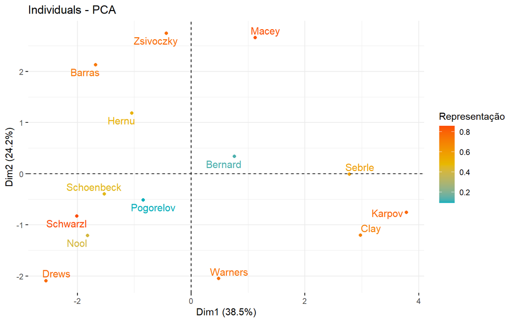

```r
fviz_pca_ind(pca,
             col.ind = "cos2", #Cor pela qualidade de representação
             gradient.cols = c("#00AFBB", "#E7B800", "#FC4E07"),
             repel = TRUE, # Texto não sobreposto
             legend.title = "Representação"
)
```

## Conclusão

Na base de dados utilizada, cada variável apresenta escalas muito diferentes, o que pode influenciar no peso excessivo de variáveis que têm uma escala naturalmente mais alta. Por este motivo, neste trabalho, realizamos análises com e sem a padronização dos dados, a fim de explicitar a diferença de ambas as análises.

Apesar da análise sem a padronização explicar uma parte maior da variabilidade, acreditamos que, a padronização nos permite uma melhor compreensão dos dados. Isto porque, ao padronizar os dados, homogeneiza-se o peso das variáveis, impedindo que um componente seja explicado por apenas variáveis que possuem escalas maiores, quando na verdade, esse componente é explicado por mais variáveis.